# Risk Factor Analysis

## Outcome Variable

**Outcome Variable:** ever_co

## Predictor Variables

**Intervention Variable:** cleanck

**Adjustment Set:**

unadjusted

## Stratifying Variables

The analysis was stratified on these variable(s):

- agecat
- studyid
- country

## Data Summary

| agecat | studyid | country | cleanck | ever_co | n_cell | n |
| --- | --- | --- | --- | --- | --- | --- |
| 0-24 months | ki0047075b-MAL-ED | PERU | 1 | 0 | 1 | 2 |
| 0-24 months | ki0047075b-MAL-ED | PERU | 1 | 1 | 0 | 2 |
| 0-24 months | ki0047075b-MAL-ED | PERU | 0 | 0 | 1 | 2 |
| 0-24 months | ki0047075b-MAL-ED | PERU | 0 | 1 | 0 | 2 |
| 0-24 months | ki0047075b-MAL-ED | SOUTH AFRICA | 1 | 0 | 1 | 3 |
| 0-24 months | ki0047075b-MAL-ED | SOUTH AFRICA | 1 | 1 | 1 | 3 |
| 0-24 months | ki0047075b-MAL-ED | SOUTH AFRICA | 0 | 0 | 1 | 3 |
| 0-24 months | ki0047075b-MAL-ED | SOUTH AFRICA | 0 | 1 | 0 | 3 |
| 0-24 months | ki1000108-CMC-V-BCS-2002 | INDIA | 1 | 0 | 142 | 373 |
| 0-24 months | ki1000108-CMC-V-BCS-2002 | INDIA | 1 | 1 | 21 | 373 |
| 0-24 months | ki1000108-CMC-V-BCS-2002 | INDIA | 0 | 0 | 145 | 373 |
| 0-24 months | ki1000108-CMC-V-BCS-2002 | INDIA | 0 | 1 | 65 | 373 |
| 0-24 months | ki1000108-IRC | INDIA | 1 | 0 | 198 | 400 |
| 0-24 months | ki1000108-IRC | INDIA | 1 | 1 | 33 | 400 |
| 0-24 months | ki1000108-IRC | INDIA | 0 | 0 | 130 | 400 |
| 0-24 months | ki1000108-IRC | INDIA | 0 | 1 | 39 | 400 |
| 0-24 months | ki1017093b-PROVIDE | BANGLADESH | 1 | 0 | 508 | 700 |
| 0-24 months | ki1017093b-PROVIDE | BANGLADESH | 1 | 1 | 63 | 700 |
| 0-24 months | ki1017093b-PROVIDE | BANGLADESH | 0 | 0 | 102 | 700 |
| 0-24 months | ki1017093b-PROVIDE | BANGLADESH | 0 | 1 | 27 | 700 |
| 0-24 months | ki1017093c-NIH-Crypto | BANGLADESH | 1 | 0 | 329 | 577 |
| 0-24 months | ki1017093c-NIH-Crypto | BANGLADESH | 1 | 1 | 31 | 577 |
| 0-24 months | ki1017093c-NIH-Crypto | BANGLADESH | 0 | 0 | 200 | 577 |
| 0-24 months | ki1017093c-NIH-Crypto | BANGLADESH | 0 | 1 | 17 | 577 |
| 0-24 months | ki1113344-GMS-Nepal | NEPAL | 1 | 0 | 10 | 612 |
| 0-24 months | ki1113344-GMS-Nepal | NEPAL | 1 | 1 | 0 | 612 |
| 0-24 months | ki1113344-GMS-Nepal | NEPAL | 0 | 0 | 421 | 612 |
| 0-24 months | ki1113344-GMS-Nepal | NEPAL | 0 | 1 | 181 | 612 |
| 0-6 months | ki0047075b-MAL-ED | PERU | 1 | 0 | 1 | 2 |
| 0-6 months | ki0047075b-MAL-ED | PERU | 1 | 1 | 0 | 2 |
| 0-6 months | ki0047075b-MAL-ED | PERU | 0 | 0 | 1 | 2 |
| 0-6 months | ki0047075b-MAL-ED | PERU | 0 | 1 | 0 | 2 |
| 0-6 months | ki0047075b-MAL-ED | SOUTH AFRICA | 1 | 0 | 1 | 3 |
| 0-6 months | ki0047075b-MAL-ED | SOUTH AFRICA | 1 | 1 | 1 | 3 |
| 0-6 months | ki0047075b-MAL-ED | SOUTH AFRICA | 0 | 0 | 1 | 3 |
| 0-6 months | ki0047075b-MAL-ED | SOUTH AFRICA | 0 | 1 | 0 | 3 |
| 0-6 months | ki1000108-CMC-V-BCS-2002 | INDIA | 1 | 0 | 156 | 368 |
| 0-6 months | ki1000108-CMC-V-BCS-2002 | INDIA | 1 | 1 | 6 | 368 |
| 0-6 months | ki1000108-CMC-V-BCS-2002 | INDIA | 0 | 0 | 181 | 368 |
| 0-6 months | ki1000108-CMC-V-BCS-2002 | INDIA | 0 | 1 | 25 | 368 |
| 0-6 months | ki1000108-IRC | INDIA | 1 | 0 | 219 | 399 |
| 0-6 months | ki1000108-IRC | INDIA | 1 | 1 | 12 | 399 |
| 0-6 months | ki1000108-IRC | INDIA | 0 | 0 | 156 | 399 |
| 0-6 months | ki1000108-IRC | INDIA | 0 | 1 | 12 | 399 |
| 0-6 months | ki1017093b-PROVIDE | BANGLADESH | 1 | 0 | 549 | 700 |
| 0-6 months | ki1017093b-PROVIDE | BANGLADESH | 1 | 1 | 22 | 700 |
| 0-6 months | ki1017093b-PROVIDE | BANGLADESH | 0 | 0 | 121 | 700 |
| 0-6 months | ki1017093b-PROVIDE | BANGLADESH | 0 | 1 | 8 | 700 |
| 0-6 months | ki1017093c-NIH-Crypto | BANGLADESH | 1 | 0 | 355 | 577 |
| 0-6 months | ki1017093c-NIH-Crypto | BANGLADESH | 1 | 1 | 5 | 577 |
| 0-6 months | ki1017093c-NIH-Crypto | BANGLADESH | 0 | 0 | 210 | 577 |
| 0-6 months | ki1017093c-NIH-Crypto | BANGLADESH | 0 | 1 | 7 | 577 |
| 0-6 months | ki1113344-GMS-Nepal | NEPAL | 1 | 0 | 10 | 612 |
| 0-6 months | ki1113344-GMS-Nepal | NEPAL | 1 | 1 | 0 | 612 |
| 0-6 months | ki1113344-GMS-Nepal | NEPAL | 0 | 0 | 572 | 612 |
| 0-6 months | ki1113344-GMS-Nepal | NEPAL | 0 | 1 | 30 | 612 |
| 6-24 months | ki0047075b-MAL-ED | SOUTH AFRICA | 1 | 0 | 1 | 1 |
| 6-24 months | ki0047075b-MAL-ED | SOUTH AFRICA | 1 | 1 | 0 | 1 |
| 6-24 months | ki0047075b-MAL-ED | SOUTH AFRICA | 0 | 0 | 0 | 1 |
| 6-24 months | ki0047075b-MAL-ED | SOUTH AFRICA | 0 | 1 | 0 | 1 |
| 6-24 months | ki1000108-CMC-V-BCS-2002 | INDIA | 1 | 0 | 147 | 373 |
| 6-24 months | ki1000108-CMC-V-BCS-2002 | INDIA | 1 | 1 | 16 | 373 |
| 6-24 months | ki1000108-CMC-V-BCS-2002 | INDIA | 0 | 0 | 156 | 373 |
| 6-24 months | ki1000108-CMC-V-BCS-2002 | INDIA | 0 | 1 | 54 | 373 |
| 6-24 months | ki1000108-IRC | INDIA | 1 | 0 | 202 | 400 |
| 6-24 months | ki1000108-IRC | INDIA | 1 | 1 | 29 | 400 |
| 6-24 months | ki1000108-IRC | INDIA | 0 | 0 | 137 | 400 |
| 6-24 months | ki1000108-IRC | INDIA | 0 | 1 | 32 | 400 |
| 6-24 months | ki1017093b-PROVIDE | BANGLADESH | 1 | 0 | 456 | 614 |
| 6-24 months | ki1017093b-PROVIDE | BANGLADESH | 1 | 1 | 51 | 614 |
| 6-24 months | ki1017093b-PROVIDE | BANGLADESH | 0 | 0 | 83 | 614 |
| 6-24 months | ki1017093b-PROVIDE | BANGLADESH | 0 | 1 | 24 | 614 |
| 6-24 months | ki1017093c-NIH-Crypto | BANGLADESH | 1 | 0 | 316 | 559 |
| 6-24 months | ki1017093c-NIH-Crypto | BANGLADESH | 1 | 1 | 27 | 559 |
| 6-24 months | ki1017093c-NIH-Crypto | BANGLADESH | 0 | 0 | 200 | 559 |
| 6-24 months | ki1017093c-NIH-Crypto | BANGLADESH | 0 | 1 | 16 | 559 |
| 6-24 months | ki1113344-GMS-Nepal | NEPAL | 1 | 0 | 8 | 529 |
| 6-24 months | ki1113344-GMS-Nepal | NEPAL | 1 | 1 | 0 | 529 |
| 6-24 months | ki1113344-GMS-Nepal | NEPAL | 0 | 0 | 348 | 529 |
| 6-24 months | ki1113344-GMS-Nepal | NEPAL | 0 | 1 | 173 | 529 |

The following strata were considered:

- agecat: 0-24 months, studyid: ki0047075b-MAL-ED, country: PERU
- agecat: 0-24 months, studyid: ki0047075b-MAL-ED, country: SOUTH AFRICA
- agecat: 0-24 months, studyid: ki1000108-CMC-V-BCS-2002, country: INDIA
- agecat: 0-24 months, studyid: ki1000108-IRC, country: INDIA
- agecat: 0-24 months, studyid: ki1017093b-PROVIDE, country: BANGLADESH
- agecat: 0-24 months, studyid: ki1017093c-NIH-Crypto, country: BANGLADESH
- agecat: 0-24 months, studyid: ki1113344-GMS-Nepal, country: NEPAL
- agecat: 0-6 months, studyid: ki0047075b-MAL-ED, country: PERU
- agecat: 0-6 months, studyid: ki0047075b-MAL-ED, country: SOUTH AFRICA
- agecat: 0-6 months, studyid: ki1000108-CMC-V-BCS-2002, country: INDIA
- agecat: 0-6 months, studyid: ki1000108-IRC, country: INDIA
- agecat: 0-6 months, studyid: ki1017093b-PROVIDE, country: BANGLADESH
- agecat: 0-6 months, studyid: ki1017093c-NIH-Crypto, country: BANGLADESH
- agecat: 0-6 months, studyid: ki1113344-GMS-Nepal, country: NEPAL
- agecat: 6-24 months, studyid: ki0047075b-MAL-ED, country: SOUTH AFRICA
- agecat: 6-24 months, studyid: ki1000108-CMC-V-BCS-2002, country: INDIA
- agecat: 6-24 months, studyid: ki1000108-IRC, country: INDIA
- agecat: 6-24 months, studyid: ki1017093b-PROVIDE, country: BANGLADESH
- agecat: 6-24 months, studyid: ki1017093c-NIH-Crypto, country: BANGLADESH
- agecat: 6-24 months, studyid: ki1113344-GMS-Nepal, country: NEPAL

### Dropped Strata

Some strata were dropped due to rare outcomes:

- agecat: 0-24 months, studyid: ki0047075b-MAL-ED, country: PERU
- agecat: 0-24 months, studyid: ki0047075b-MAL-ED, country: SOUTH AFRICA
- agecat: 0-24 months, studyid: ki1113344-GMS-Nepal, country: NEPAL
- agecat: 0-6 months, studyid: ki0047075b-MAL-ED, country: PERU
- agecat: 0-6 months, studyid: ki0047075b-MAL-ED, country: SOUTH AFRICA
- agecat: 0-6 months, studyid: ki1113344-GMS-Nepal, country: NEPAL
- agecat: 6-24 months, studyid: ki0047075b-MAL-ED, country: SOUTH AFRICA
- agecat: 6-24 months, studyid: ki1113344-GMS-Nepal, country: NEPAL

## Methods Detail

We’re interested in the causal parameters $E[Y_a]$ for all values of $a \in \mathcal{A}$. These parameters represent the mean outcome if, possibly contrary to fact, we intervened to set all units to have $A=a$. Under the randomization and positivity assumptions, these are identified by the statistical parameters $\psi_a=E_W[E_{Y|A,W}(Y|A=a,W)]$. In addition, we’re interested in the mean of $Y$, $E[Y]$ under no intervention (the observed mean). We will estimate these parameters by using SuperLearner to fit the relevant likelihood factors – $E_{Y|A,W}(Y|A=a,W)$ and $p(A=a|W)$, and then updating our likelihood fit using a joint TMLE.

For unadjusted analyses ($W=\{\}$), initial likelihoods were estimated using Lrnr_glm to estimate the simple $E(Y|A)$ and Lrnr_mean to estimate $p(A)$. For adjusted analyses, a small library containing Lrnr_glmnet, Lrnr_xgboost, and Lrnr_mean was used.

Having estimated these parameters, we will then use the delta method to estimate relative risks and attributable risks relative to a prespecified baseline level of $A$.

# Results Detail

## Results Plots

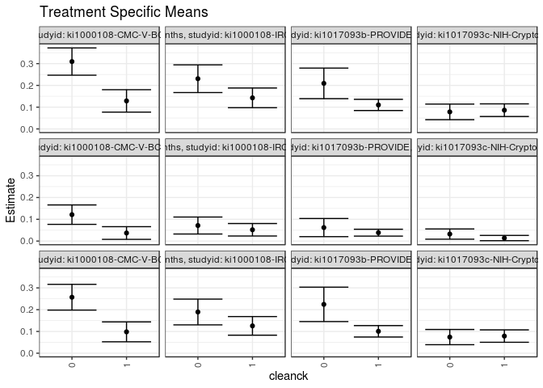

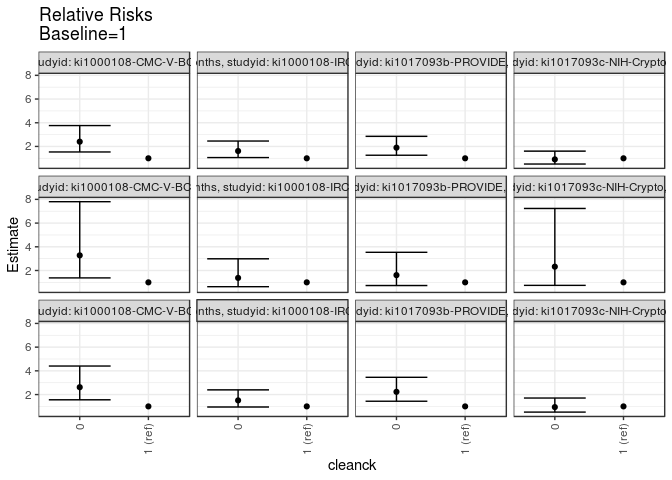

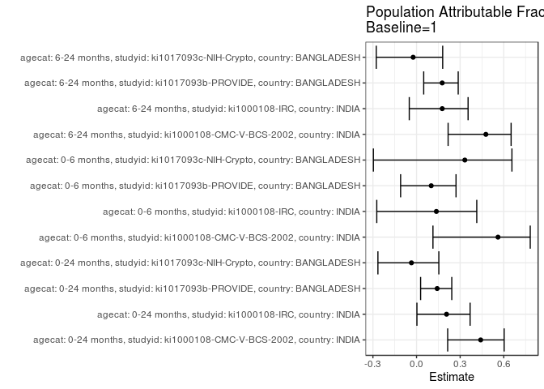

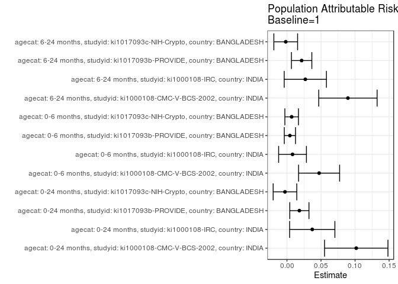

## Results Table

### Parameter: TSM

| agecat | studyid | country | intervention_level | baseline_level | estimate | ci_lower | ci_upper |
| --- | --- | --- | --- | --- | --- | --- | --- |
| 0-24 months | ki1000108-CMC-V-BCS-2002 | INDIA | 1 | NA | 0.1288344 | 0.0773348 | 0.1803339 |
| 0-24 months | ki1000108-CMC-V-BCS-2002 | INDIA | 0 | NA | 0.3095238 | 0.2469139 | 0.3721337 |
| 0-24 months | ki1000108-IRC | INDIA | 1 | NA | 0.1428571 | 0.0976754 | 0.1880389 |
| 0-24 months | ki1000108-IRC | INDIA | 0 | NA | 0.2307692 | 0.1671680 | 0.2943705 |
| 0-24 months | ki1017093b-PROVIDE | BANGLADESH | 1 | NA | 0.1103327 | 0.0846166 | 0.1360489 |
| 0-24 months | ki1017093b-PROVIDE | BANGLADESH | 0 | NA | 0.2093023 | 0.1390508 | 0.2795539 |
| 0-24 months | ki1017093c-NIH-Crypto | BANGLADESH | 1 | NA | 0.0861111 | 0.0571077 | 0.1151146 |
| 0-24 months | ki1017093c-NIH-Crypto | BANGLADESH | 0 | NA | 0.0783410 | 0.0425582 | 0.1141238 |
| 0-6 months | ki1000108-CMC-V-BCS-2002 | INDIA | 1 | NA | 0.0370370 | 0.0079162 | 0.0661579 |
| 0-6 months | ki1000108-CMC-V-BCS-2002 | INDIA | 0 | NA | 0.1213592 | 0.0767066 | 0.1660119 |
| 0-6 months | ki1000108-IRC | INDIA | 1 | NA | 0.0519481 | 0.0232939 | 0.0806022 |
| 0-6 months | ki1000108-IRC | INDIA | 0 | NA | 0.0714286 | 0.0324360 | 0.1104212 |
| 0-6 months | ki1017093b-PROVIDE | BANGLADESH | 1 | NA | 0.0385289 | 0.0227309 | 0.0543269 |
| 0-6 months | ki1017093b-PROVIDE | BANGLADESH | 0 | NA | 0.0620155 | 0.0203658 | 0.1036652 |
| 0-6 months | ki1017093c-NIH-Crypto | BANGLADESH | 1 | NA | 0.0138889 | 0.0017893 | 0.0259885 |
| 0-6 months | ki1017093c-NIH-Crypto | BANGLADESH | 0 | NA | 0.0322581 | 0.0087296 | 0.0557865 |
| 6-24 months | ki1000108-CMC-V-BCS-2002 | INDIA | 1 | NA | 0.0981595 | 0.0524224 | 0.1438966 |
| 6-24 months | ki1000108-CMC-V-BCS-2002 | INDIA | 0 | NA | 0.2571429 | 0.1979511 | 0.3163346 |
| 6-24 months | ki1000108-IRC | INDIA | 1 | NA | 0.1255411 | 0.0827604 | 0.1683219 |
| 6-24 months | ki1000108-IRC | INDIA | 0 | NA | 0.1893491 | 0.1302070 | 0.2484912 |
| 6-24 months | ki1017093b-PROVIDE | BANGLADESH | 1 | NA | 0.1005917 | 0.0743883 | 0.1267951 |
| 6-24 months | ki1017093b-PROVIDE | BANGLADESH | 0 | NA | 0.2242991 | 0.1452001 | 0.3033981 |
| 6-24 months | ki1017093c-NIH-Crypto | BANGLADESH | 1 | NA | 0.0787172 | 0.0501925 | 0.1072419 |
| 6-24 months | ki1017093c-NIH-Crypto | BANGLADESH | 0 | NA | 0.0740741 | 0.0391173 | 0.1090308 |

### Parameter: E(Y)

| agecat | studyid | country | intervention_level | baseline_level | estimate | ci_lower | ci_upper |
| --- | --- | --- | --- | --- | --- | --- | --- |
| 0-24 months | ki1000108-CMC-V-BCS-2002 | INDIA | NA | NA | 0.2305630 | 0.1877616 | 0.2733644 |
| 0-24 months | ki1000108-IRC | INDIA | NA | NA | 0.1800000 | 0.1423032 | 0.2176968 |
| 0-24 months | ki1017093b-PROVIDE | BANGLADESH | NA | NA | 0.1285714 | 0.1037574 | 0.1533855 |
| 0-24 months | ki1017093c-NIH-Crypto | BANGLADESH | NA | NA | 0.0831889 | 0.0606356 | 0.1057422 |
| 0-6 months | ki1000108-CMC-V-BCS-2002 | INDIA | NA | NA | 0.0842391 | 0.0558231 | 0.1126551 |
| 0-6 months | ki1000108-IRC | INDIA | NA | NA | 0.0601504 | 0.0367913 | 0.0835094 |
| 0-6 months | ki1017093b-PROVIDE | BANGLADESH | NA | NA | 0.0428571 | 0.0278427 | 0.0578716 |
| 0-6 months | ki1017093c-NIH-Crypto | BANGLADESH | NA | NA | 0.0207972 | 0.0091432 | 0.0324513 |
| 6-24 months | ki1000108-CMC-V-BCS-2002 | INDIA | NA | NA | 0.1876676 | 0.1479906 | 0.2273445 |
| 6-24 months | ki1000108-IRC | INDIA | NA | NA | 0.1525000 | 0.1172250 | 0.1877750 |
| 6-24 months | ki1017093b-PROVIDE | BANGLADESH | NA | NA | 0.1221498 | 0.0962275 | 0.1480722 |
| 6-24 months | ki1017093c-NIH-Crypto | BANGLADESH | NA | NA | 0.0769231 | 0.0548136 | 0.0990325 |

### Parameter: RR

| agecat | studyid | country | intervention_level | baseline_level | estimate | ci_lower | ci_upper |
| --- | --- | --- | --- | --- | --- | --- | --- |
| 0-24 months | ki1000108-CMC-V-BCS-2002 | INDIA | 1 | 1 | 1.0000000 | 1.0000000 | 1.000000 |
| 0-24 months | ki1000108-CMC-V-BCS-2002 | INDIA | 0 | 1 | 2.4024943 | 1.5349646 | 3.760334 |
| 0-24 months | ki1000108-IRC | INDIA | 1 | 1 | 1.0000000 | 1.0000000 | 1.000000 |
| 0-24 months | ki1000108-IRC | INDIA | 0 | 1 | 1.6153846 | 1.0619062 | 2.457343 |
| 0-24 months | ki1017093b-PROVIDE | BANGLADESH | 1 | 1 | 1.0000000 | 1.0000000 | 1.000000 |
| 0-24 months | ki1017093b-PROVIDE | BANGLADESH | 0 | 1 | 1.8970100 | 1.2606686 | 2.854554 |
| 0-24 months | ki1017093c-NIH-Crypto | BANGLADESH | 1 | 1 | 1.0000000 | 1.0000000 | 1.000000 |
| 0-24 months | ki1017093c-NIH-Crypto | BANGLADESH | 0 | 1 | 0.9097666 | 0.5157773 | 1.604715 |
| 0-6 months | ki1000108-CMC-V-BCS-2002 | INDIA | 1 | 1 | 1.0000000 | 1.0000000 | 1.000000 |
| 0-6 months | ki1000108-CMC-V-BCS-2002 | INDIA | 0 | 1 | 3.2766990 | 1.3753959 | 7.806302 |
| 0-6 months | ki1000108-IRC | INDIA | 1 | 1 | 1.0000000 | 1.0000000 | 1.000000 |
| 0-6 months | ki1000108-IRC | INDIA | 0 | 1 | 1.3750000 | 0.6328015 | 2.987706 |
| 0-6 months | ki1017093b-PROVIDE | BANGLADESH | 1 | 1 | 1.0000000 | 1.0000000 | 1.000000 |
| 0-6 months | ki1017093b-PROVIDE | BANGLADESH | 0 | 1 | 1.6095842 | 0.7327878 | 3.535487 |
| 0-6 months | ki1017093c-NIH-Crypto | BANGLADESH | 1 | 1 | 1.0000000 | 1.0000000 | 1.000000 |
| 0-6 months | ki1017093c-NIH-Crypto | BANGLADESH | 0 | 1 | 2.3225806 | 0.7456384 | 7.234581 |
| 6-24 months | ki1000108-CMC-V-BCS-2002 | INDIA | 1 | 1 | 1.0000000 | 1.0000000 | 1.000000 |
| 6-24 months | ki1000108-CMC-V-BCS-2002 | INDIA | 0 | 1 | 2.6196428 | 1.5578906 | 4.405013 |
| 6-24 months | ki1000108-IRC | INDIA | 1 | 1 | 1.0000000 | 1.0000000 | 1.000000 |
| 6-24 months | ki1000108-IRC | INDIA | 0 | 1 | 1.5082636 | 0.9499934 | 2.394605 |
| 6-24 months | ki1017093b-PROVIDE | BANGLADESH | 1 | 1 | 1.0000000 | 1.0000000 | 1.000000 |
| 6-24 months | ki1017093b-PROVIDE | BANGLADESH | 0 | 1 | 2.2297966 | 1.4383309 | 3.456779 |
| 6-24 months | ki1017093c-NIH-Crypto | BANGLADESH | 1 | 1 | 1.0000000 | 1.0000000 | 1.000000 |
| 6-24 months | ki1017093c-NIH-Crypto | BANGLADESH | 0 | 1 | 0.9410151 | 0.5190324 | 1.706077 |

### Parameter: PAR

| agecat | studyid | country | intervention_level | baseline_level | estimate | ci_lower | ci_upper |
| --- | --- | --- | --- | --- | --- | --- | --- |
| 0-24 months | ki1000108-CMC-V-BCS-2002 | INDIA | 1 | NA | 0.1017286 | 0.0551867 | 0.1482706 |
| 0-24 months | ki1000108-IRC | INDIA | 1 | NA | 0.0371429 | 0.0039068 | 0.0703789 |
| 0-24 months | ki1017093b-PROVIDE | BANGLADESH | 1 | NA | 0.0182387 | 0.0041618 | 0.0323156 |
| 0-24 months | ki1017093c-NIH-Crypto | BANGLADESH | 1 | NA | -0.0029222 | -0.0202477 | 0.0144033 |
| 0-6 months | ki1000108-CMC-V-BCS-2002 | INDIA | 1 | NA | 0.0472021 | 0.0170547 | 0.0773495 |
| 0-6 months | ki1000108-IRC | INDIA | 1 | NA | 0.0082023 | -0.0121938 | 0.0285985 |
| 0-6 months | ki1017093b-PROVIDE | BANGLADESH | 1 | NA | 0.0043282 | -0.0039085 | 0.0125650 |
| 0-6 months | ki1017093c-NIH-Crypto | BANGLADESH | 1 | NA | 0.0069083 | -0.0030683 | 0.0168850 |
| 6-24 months | ki1000108-CMC-V-BCS-2002 | INDIA | 1 | NA | 0.0895080 | 0.0466379 | 0.1323782 |
| 6-24 months | ki1000108-IRC | INDIA | 1 | NA | 0.0269589 | -0.0040354 | 0.0579531 |
| 6-24 months | ki1017093b-PROVIDE | BANGLADESH | 1 | NA | 0.0215581 | 0.0065694 | 0.0365468 |
| 6-24 months | ki1017093c-NIH-Crypto | BANGLADESH | 1 | NA | -0.0017941 | -0.0192289 | 0.0156407 |

### Parameter: PAF

| agecat | studyid | country | intervention_level | baseline_level | estimate | ci_lower | ci_upper |
| --- | --- | --- | --- | --- | --- | --- | --- |
| 0-24 months | ki1000108-CMC-V-BCS-2002 | INDIA | 1 | NA | 0.4412184 | 0.2142334 | 0.6026341 |
| 0-24 months | ki1000108-IRC | INDIA | 1 | NA | 0.2063492 | 0.0026453 | 0.3684477 |
| 0-24 months | ki1017093b-PROVIDE | BANGLADESH | 1 | NA | 0.1418564 | 0.0280124 | 0.2423664 |
| 0-24 months | ki1017093c-NIH-Crypto | BANGLADESH | 1 | NA | -0.0351273 | -0.2656079 | 0.1533804 |
| 0-6 months | ki1000108-CMC-V-BCS-2002 | INDIA | 1 | NA | 0.5603345 | 0.1129210 | 0.7820874 |
| 0-6 months | ki1000108-IRC | INDIA | 1 | NA | 0.1363636 | -0.2734637 | 0.4142999 |
| 0-6 months | ki1017093b-PROVIDE | BANGLADESH | 1 | NA | 0.1009924 | -0.1095560 | 0.2715873 |
| 0-6 months | ki1017093c-NIH-Crypto | BANGLADESH | 1 | NA | 0.3321759 | -0.2968904 | 0.6561089 |
| 6-24 months | ki1000108-CMC-V-BCS-2002 | INDIA | 1 | NA | 0.4769500 | 0.2172135 | 0.6505033 |
| 6-24 months | ki1000108-IRC | INDIA | 1 | NA | 0.1767795 | -0.0500229 | 0.3545931 |
| 6-24 months | ki1017093b-PROVIDE | BANGLADESH | 1 | NA | 0.1764891 | 0.0493635 | 0.2866147 |
| 6-24 months | ki1017093c-NIH-Crypto | BANGLADESH | 1 | NA | -0.0233236 | -0.2769341 | 0.1799175 |